# Case Study 2_DDS Analytics

Audrene Tiakor

April 16, 2019

```r
library(dplyr)
library(Hmisc)
library(corrplot)
library(ggplot2)
library(SmartEDA)
library(MASS)
library(tidyverse)
library(caret)
library(knitr)
library(kableExtra)
library(caTools)
library(randomForest)
library(e1071)
library(pROC)
```

# Introduction

Working with the data science team at DDSAnalytics, our team has been given the assignment to conduct an analysis with existing employee data to identify predicting employee turnover and monthly income for Frito Lay. To effectively identify predicting employee turnover and monthly income, first, exploratory data analysis (EDA) will be used. During exploratory analysis we will assess which variables in the dataset are highly correlated with employee turnover and monthly income. After EDA, predictive models will be constructed using Logistic and Linear Regression Models, Naive Bayes model, and Random Forest Model. Using AIC, RMSE, and the roc function to find the best model, the best model will then be used to predict employee turnover and monthly income.

```r
#Import Train Data
turnover<-read.csv("CaseStudy2-data.csv", header=TRUE, stringsAsFactors=TRUE)
kable(turnover %>% head()) %>% kable_styling(turnover, bootstrap_options = "striped", full_width = F, position = "center")
```

| ID | Age | Attrition | BusinessTravel | DailyRate | Department | DistanceFromHome | Education | EducationField | EmployeeCount | EmployeeNumber | EnvironmentSatisfaction | Gender | HourlyRate | JobInvolvement | JobLevel | JobRole | JobSatisfaction | MaritalStatus | MonthlyIncome | MonthlyRate | NumCompaniesWorked | Over18 | OverTime | PercentSalaryHike | PerformanceRating | RelationshipSatisfaction | StandardHours | StockOptionLevel | TotalWorkingYears | … |
| --- | --- | --- | --- | --- | --- | --- | --- | --- | --- | --- | --- | --- | --- | --- | --- | --- | --- | --- | --- | --- | --- | --- | --- | --- | --- | --- | --- | --- | --- | --- |
| 1 | 32 | No | Travel_Rarely | 117 | Sales | 13 | 4 | Life Sciences | 1 | 859 | 2 | Male | 73 | 3 | 2 | Sales Executive | 4 | Divorced | 4403 | 9250 | 2 | Y | No | 11 | 3 | 3 | 80 | 1 | 8 | … |
| 2 | 40 | No | Travel_Rarely | 1308 | Research & Development | 14 | 3 | Medical | 1 | 1128 | 3 | Male | 44 | 2 | 5 | Research Director | 3 | Single | 19626 | 17544 | 1 | Y | No | 14 | 3 | 1 | 80 | 0 | 21 | … |
| 3 | 35 | No | Travel_Frequently | 200 | Research & Development | 18 | 2 | Life Sciences | 1 | 1412 | 3 | Male | 60 | 3 | 3 | Manufacturing Director | 4 | Single | 9362 | 19944 | 2 | Y | No | 11 | 3 | 3 | 80 | 0 | 10 | … |
| 4 | 32 | No | Travel_Rarely | 801 | Sales | 1 | 4 | Marketing | 1 | 2016 | 3 | Female | 48 | 3 | 3 | Sales Executive | 4 | Married | 10422 | 24032 | 1 | Y | No | 19 | 3 | 3 | 80 | 2 | 14 | … |
| 5 | 24 | No | Travel_Frequently | 567 | Research & Development | 2 | 1 | Technical Degree | 1 | 1646 | 1 | Female | 32 | 3 | 1 | Research Scientist | 4 | Single | 3760 | 17218 | 1 | Y | Yes | 13 | 3 | 3 | 80 | 0 | 6 | … |
| 6 | 27 | No | Travel_Frequently | 294 | Research & Development | 10 | 2 | Life Sciences | 1 | 733 | 4 | Male | 32 | 3 | 3 | Manufacturing Director | 1 | Divorced | 8793 | 4809 | 1 | Y | No | 21 | 4 | 3 | 80 | 2 | 9 | … |

```r
#Import Test Data
turntest<-read.csv("CaseStudy2Validation No Attrition.csv", header=TRUE, stringsAsFactors=TRUE)
kable(turntest) %>% kable_styling(bootstrap_options = "striped", full_width = F, position = "center")
```

[output not shown]

[output cut: 270 more lines]

```r
#check for missing values
missing<-ExpData(data=turnover, type=2)
kable(missing) %>% kable_styling(bootstrap_options = "striped", full_width = F, position = "center")
```

| S.no | Variable Name | Variable Type | % of Missing | No. of Unique values |
| --- | --- | --- | --- | --- |
| 1 | ID | integer | 0 | 870 |
| 2 | Age | integer | 0 | 43 |
| 3 | Attrition* | factor | 0 | 2 |
| 4 | BusinessTravel* | factor | 0 | 3 |
| 5 | DailyRate | integer | 0 | 627 |
| 6 | Department* | factor | 0 | 3 |
| 7 | DistanceFromHome | integer | 0 | 29 |
| 8 | Education | integer | 0 | 5 |
| 9 | EducationField* | factor | 0 | 6 |
| 10 | EmployeeCount | integer | 0 | 1 |
| 11 | EmployeeNumber | integer | 0 | 870 |
| 12 | EnvironmentSatisfaction | integer | 0 | 4 |
| 13 | Gender* | factor | 0 | 2 |
| 14 | HourlyRate | integer | 0 | 71 |
| 15 | JobInvolvement | integer | 0 | 4 |
| 16 | JobLevel | integer | 0 | 5 |
| 17 | JobRole* | factor | 0 | 9 |
| 18 | JobSatisfaction | integer | 0 | 4 |
| 19 | MaritalStatus* | factor | 0 | 3 |
| 20 | MonthlyIncome | integer | 0 | 826 |
| 21 | MonthlyRate | integer | 0 | 852 |
| 22 | NumCompaniesWorked | integer | 0 | 10 |
| 23 | Over18* | factor | 0 | 1 |
| 24 | OverTime* | factor | 0 | 2 |
| 25 | PercentSalaryHike | integer | 0 | 15 |
| 26 | PerformanceRating | integer | 0 | 2 |
| 27 | RelationshipSatisfaction | integer | 0 | 4 |
| 28 | StandardHours | integer | 0 | 1 |
| 29 | StockOptionLevel | integer | 0 | 4 |
| 30 | TotalWorkingYears | integer | 0 | 39 |
| 31 | TrainingTimesLastYear | integer | 0 | 7 |
| 32 | WorkLifeBalance | integer | 0 | 4 |
| 33 | YearsAtCompany | integer | 0 | 32 |
| 34 | YearsInCurrentRole | integer | 0 | 19 |
| 35 | YearsSinceLastPromotion | integer | 0 | 16 |
| 36 | YearsWithCurrManager | integer | 0 | 17 |
| 37 | Rand | numeric | 0 | 870 |

```r
#See an overview of the data
overview<-ExpData(data=turnover, type=1)
kable(overview) %>% kable_styling(bootstrap_options = "striped", full_width = F, position = "center")
```

| Descriptions | Obs |
| --- | --- |
| Sample size (Nrow) | 870 |
| No. of Variables (Ncol) | 37 |
| No. of Numeric Variables | 28 |
| No. of Factor Variables | 9 |
| No. of Text Variables | 0 |
| No. of Logical Variables | 0 |
| No. of Date Variables | 0 |
| No. of Zero variance Variables (Uniform) | 3 |
| %. of Variables having complete cases | 100% (37) |
| %. of Variables having <50% missing cases | 0% (0) |
| %. of Variables having >50% missing cases | 0% (0) |
| %. of Variables having >90% missing cases | 0% (0) |

# ANALYSIS I: ATTRITION AT FRITO LAY

## Exploratory Data Analysis (EDA)

```r
stat_sum<-ExpNumStat(turnover, by="GA", gp="Attrition", Qnt=seq(0,1,0.1), MesofShape=2, Outlier=TRUE, round=2)
kable(stat_sum) %>% kable_styling(bootstrap_options = "striped", full_width = F, position = "center")
```

|  | Vname | Group | TN | nNeg | nZero | nPos | NegInf | PosInf | NA_Value | Per_of_Missing | sum | min | max | mean | median | SD | CV | IQR | Skweness | Kurtosis | 0% | 10% | 20% | 30% | 40% | 50% | 60% | 70% | 80% | … |
| --- | --- | --- | --- | --- | --- | --- | --- | --- | --- | --- | --- | --- | --- | --- | --- | --- | --- | --- | --- | --- | --- | --- | --- | --- | --- | --- | --- | --- | --- | --- |
| 2 | Age | Attrition:All | 870 | 0 | 0 | 870 | 0 | 0 | 0 | 0 | 32041.00 | 18.00 | 60 | 36.83 | 35.00 | 8.93 | 0.24 | 13.00 | 0.42 | -0.30 | 18.00 | 26.00 | 29.00 | 31.70 | 34.00 | 35.00 | 38.00 | 41.00 | 45.00 | … |
| 18 | Age | Attrition:No | 730 | 0 | 0 | 730 | 0 | 0 | 0 | 0 | 27311.00 | 18.00 | 60 | 37.41 | 36.00 | 8.67 | 0.23 | 12.00 | 0.43 | -0.32 | 18.00 | 27.00 | 30.00 | 32.00 | 34.00 | 36.00 | 38.00 | 42.00 | 45.00 | … |
| 34 | Age | Attrition:Yes | 140 | 0 | 0 | 140 | 0 | 0 | 0 | 0 | 4730.00 | 18.00 | 58 | 33.79 | 32.00 | 9.61 | 0.28 | 11.00 | 0.67 | -0.03 | 18.00 | 22.00 | 26.80 | 29.00 | 30.00 | 32.00 | 34.00 | 36.00 | 41.00 | … |
| 3 | DailyRate | Attrition:All | 870 | 0 | 0 | 870 | 0 | 0 | 0 | 0 | 709248.00 | 103.00 | 1499 | 815.23 | 817.50 | 401.12 | 0.49 | 693.25 | -0.03 | -1.18 | 103.00 | 257.80 | 408.00 | 541.70 | 686.80 | 817.50 | 947.20 | 1107.00 | 1225.00 | … |
| 19 | DailyRate | Attrition:No | 730 | 0 | 0 | 730 | 0 | 0 | 0 | 0 | 599447.00 | 111.00 | 1499 | 821.16 | 828.50 | 401.41 | 0.49 | 694.50 | -0.07 | -1.17 | 111.00 | 252.90 | 427.00 | 548.00 | 692.00 | 828.50 | 956.40 | 1119.10 | 1229.40 | … |
| 35 | DailyRate | Attrition:Yes | 140 | 0 | 0 | 140 | 0 | 0 | 0 | 0 | 109801.00 | 103.00 | 1496 | 784.29 | 751.00 | 399.56 | 0.51 | 682.00 | 0.17 | -1.19 | 103.00 | 286.70 | 357.20 | 502.80 | 613.80 | 751.00 | 887.00 | 1064.80 | 1170.40 | … |
| 4 | DistanceFromHome | Attrition:All | 870 | 0 | 0 | 870 | 0 | 0 | 0 | 0 | 8125.00 | 1.00 | 29 | 9.34 | 7.00 | 8.14 | 0.87 | 12.00 | 0.91 | -0.35 | 1.00 | 1.00 | 2.00 | 3.00 | 5.00 | 7.00 | 9.00 | 11.00 | 17.00 | … |
| 20 | DistanceFromHome | Attrition:No | 730 | 0 | 0 | 730 | 0 | 0 | 0 | 0 | 6591.00 | 1.00 | 29 | 9.03 | 7.00 | 7.98 | 0.88 | 11.00 | 1.00 | -0.13 | 1.00 | 1.00 | 2.00 | 3.00 | 5.00 | 7.00 | 9.00 | 10.00 | 16.00 | … |
| 36 | DistanceFromHome | Attrition:Yes | 140 | 0 | 0 | 140 | 0 | 0 | 0 | 0 | 1534.00 | 1.00 | 29 | 10.96 | 9.00 | 8.75 | 0.80 | 16.00 | 0.53 | -1.08 | 1.00 | 1.00 | 2.00 | 3.70 | 6.60 | 9.00 | 11.40 | 16.00 | 21.20 | … |
| 5 | EmployeeNumber | Attrition:All | 870 | 0 | 0 | 870 | 0 | 0 | 0 | 0 | 895954.00 | 1.00 | 2064 | 1029.83 | 1039.00 | 604.79 | 0.59 | 1084.25 | -0.03 | -1.24 | 1.00 | 191.10 | 389.60 | 609.20 | 833.60 | 1039.00 | 1244.20 | 1467.30 | 1656.40 | … |
| 21 | EmployeeNumber | Attrition:No | 730 | 0 | 0 | 730 | 0 | 0 | 0 | 0 | 756182.00 | 11.00 | 2064 | 1035.87 | 1049.50 | 606.52 | 0.59 | 1095.25 | -0.03 | -1.24 | 11.00 | 197.90 | 390.80 | 612.70 | 833.60 | 1049.50 | 1258.40 | 1472.30 | 1656.40 | … |
| 37 | EmployeeNumber | Attrition:Yes | 140 | 0 | 0 | 140 | 0 | 0 | 0 | 0 | 139772.00 | 1.00 | 2027 | 998.37 | 1021.50 | 596.86 | 0.60 | 1025.25 | -0.03 | -1.20 | 1.00 | 162.80 | 373.60 | 578.30 | 859.80 | 1021.50 | 1158.20 | 1391.30 | 1652.60 | … |
| 6 | HourlyRate | Attrition:All | 870 | 0 | 0 | 870 | 0 | 0 | 0 | 0 | 57084.00 | 30.00 | 100 | 65.61 | 66.00 | 20.13 | 0.31 | 35.00 | 0.01 | -1.20 | 30.00 | 39.00 | 45.00 | 51.00 | 58.00 | 66.00 | 73.00 | 80.00 | 86.00 | … |
| 22 | HourlyRate | Attrition:No | 730 | 0 | 0 | 730 | 0 | 0 | 0 | 0 | 47663.00 | 30.00 | 100 | 65.29 | 64.50 | 20.20 | 0.31 | 34.75 | 0.02 | -1.22 | 30.00 | 39.00 | 44.80 | 51.00 | 57.00 | 64.50 | 73.00 | 80.00 | 86.00 | … |
| 38 | HourlyRate | Attrition:Yes | 140 | 0 | 0 | 140 | 0 | 0 | 0 | 0 | 9421.00 | 32.00 | 100 | 67.29 | 68.50 | 19.71 | 0.29 | 33.00 | -0.05 | -1.10 | 32.00 | 38.90 | 47.80 | 54.00 | 62.00 | 68.50 | 72.40 | 79.30 | 86.00 | … |
| 1 | ID | Attrition:All | 870 | 0 | 0 | 870 | 0 | 0 | 0 | 0 | 378885.00 | 1.00 | 870 | 435.50 | 435.50 | 251.29 | 0.58 | 434.50 | 0.00 | -1.20 | 1.00 | 87.90 | 174.80 | 261.70 | 348.60 | 435.50 | 522.40 | 609.30 | 696.20 | … |
| 17 | ID | Attrition:No | 730 | 0 | 0 | 730 | 0 | 0 | 0 | 0 | 314120.00 | 1.00 | 870 | 430.30 | 425.50 | 251.32 | 0.58 | 432.00 | 0.03 | -1.19 | 1.00 | 86.90 | 170.80 | 254.40 | 342.60 | 425.50 | 516.80 | 601.30 | 690.20 | … |
| 33 | ID | Attrition:Yes | 140 | 0 | 0 | 140 | 0 | 0 | 0 | 0 | 64765.00 | 28.00 | 863 | 462.61 | 485.50 | 250.27 | 0.54 | 428.25 | -0.14 | -1.20 | 28.00 | 91.60 | 206.40 | 298.70 | 388.00 | 485.50 | 550.60 | 645.60 | 721.00 | … |
| 7 | MonthlyIncome | Attrition:All | 870 | 0 | 0 | 870 | 0 | 0 | 0 | 0 | 5559530.00 | 1081.00 | 19999 | 6390.26 | 4945.50 | 4597.70 | 0.72 | 5342.50 | 1.39 | 1.15 | 1081.00 | 2278.80 | 2656.60 | 3223.60 | 4239.60 | 4945.50 | 5739.20 | 6836.40 | 9700.20 | … |
| 23 | MonthlyIncome | Attrition:No | 730 | 0 | 0 | 730 | 0 | 0 | 0 | 0 | 4892460.00 | 1129.00 | 19999 | 6702.00 | 5208.50 | 4675.47 | 0.70 | 5574.50 | 1.30 | 0.82 | 1129.00 | 2331.70 | 2792.60 | 3666.30 | 4477.60 | 5208.50 | 6030.20 | 7126.20 | 10012.00 | … |
| 39 | MonthlyIncome | Attrition:Yes | 140 | 0 | 0 | 140 | 0 | 0 | 0 | 0 | 667070.00 | 1081.00 | 19859 | 4764.79 | 3171.00 | 3786.39 | 0.79 | 3497.25 | 2.07 | 4.71 | 1081.00 | 2040.60 | 2300.20 | 2411.50 | 2689.00 | 3171.00 | 4284.80 | 4964.80 | 6685.40 | … |
| 8 | MonthlyRate | Attrition:All | 870 | 0 | 0 | 870 | 0 | 0 | 0 | 0 | 12463290.00 | 2094.00 | 26997 | 14325.62 | 14074.50 | 7108.38 | 0.50 | 12364.25 | 0.04 | -1.21 | 2094.00 | 4751.20 | 6990.80 | 9150.00 | 11713.00 | 14074.50 | 16483.40 | 19372.50 | 21784.20 | … |
| 24 | MonthlyRate | Attrition:No | 730 | 0 | 0 | 730 | 0 | 0 | 0 | 0 | 10555890.00 | 2094.00 | 26997 | 14460.12 | 14235.50 | 7126.98 | 0.49 | 12453.50 | 0.01 | -1.22 | 2094.00 | 4896.90 | 7093.60 | 9232.60 | 11924.60 | 14235.50 | 16864.00 | 19627.90 | 21985.20 | … |
| 40 | MonthlyRate | Attrition:Yes | 140 | 0 | 0 | 140 | 0 | 0 | 0 | 0 | 1907400.00 | 2396.00 | 26959 | 13624.29 | 12651.00 | 6993.82 | 0.51 | 11443.75 | 0.18 | -1.10 | 2396.00 | 4288.30 | 6701.80 | 9143.70 | 10762.00 | 12651.00 | 15406.40 | 17934.60 | 21497.80 | … |
| 9 | NumCompaniesWorked | Attrition:All | 870 | 0 | 111 | 759 | 0 | 0 | 0 | 0 | 2373.00 | 0.00 | 9 | 2.73 | 2.00 | 2.52 | 0.92 | 3.00 | 1.00 | -0.06 | 0.00 | 0.00 | 1.00 | 1.00 | 1.00 | 2.00 | 3.00 | 4.00 | 5.00 | … |
| 25 | NumCompaniesWorked | Attrition:No | 730 | 0 | 100 | 630 | 0 | 0 | 0 | 0 | 1942.00 | 0.00 | 9 | 2.66 | 2.00 | 2.47 | 0.93 | 3.00 | 1.04 | 0.10 | 0.00 | 0.00 | 1.00 | 1.00 | 1.00 | 2.00 | 3.00 | 4.00 | 4.00 | … |
| 41 | NumCompaniesWorked | Attrition:Yes | 140 | 0 | 11 | 129 | 0 | 0 | 0 | 0 | 431.00 | 0.00 | 9 | 3.08 | 1.00 | 2.77 | 0.90 | 4.00 | 0.80 | -0.75 | 0.00 | 1.00 | 1.00 | 1.00 | 1.00 | 1.00 | 3.00 | 5.00 | 6.00 | … |
| 10 | PercentSalaryHike | Attrition:All | 870 | 0 | 0 | 870 | 0 | 0 | 0 | 0 | 13224.00 | 11.00 | 25 | 15.20 | 14.00 | 3.68 | 0.24 | 6.00 | 0.83 | -0.28 | 11.00 | 11.00 | 12.00 | 13.00 | 13.00 | 14.00 | 15.00 | 17.00 | 18.00 | … |
| 26 | PercentSalaryHike | Attrition:No | 730 | 0 | 0 | 730 | 0 | 0 | 0 | 0 | 11078.00 | 11.00 | 25 | 15.18 | 14.00 | 3.63 | 0.24 | 6.00 | 0.83 | -0.25 | 11.00 | 11.00 | 12.00 | 13.00 | 13.00 | 14.00 | 15.00 | 17.00 | 18.00 | … |
| 42 | PercentSalaryHike | Attrition:Yes | 140 | 0 | 0 | 140 | 0 | 0 | 0 | 0 | 2146.00 | 11.00 | 25 | 15.33 | 14.00 | 3.93 | 0.26 | 6.00 | 0.81 | -0.43 | 11.00 | 11.00 | 12.00 | 13.00 | 13.00 | 14.00 | 16.00 | 17.00 | 18.20 | … |
| 16 | Rand | Attrition:All | 870 | 580 | 0 | 290 | 0 | 0 | 0 | 0 | -382.31 | -3.02 | 1 | -0.44 | -0.32 | 0.73 | -1.66 | 1.00 | -0.64 | 0.09 | -3.02 | -1.48 | -1.04 | -0.75 | -0.54 | -0.32 | -0.12 | 0.03 | 0.18 | … |
| 32 | Rand | Attrition:No | 730 | 494 | 0 | 236 | 0 | 0 | 0 | 0 | -334.22 | -3.02 | 1 | -0.46 | -0.35 | 0.73 | -1.60 | 1.00 | -0.67 | 0.14 | -3.02 | -1.49 | -1.06 | -0.77 | -0.55 | -0.35 | -0.13 | 0.02 | 0.17 | … |
| 48 | Rand | Attrition:Yes | 140 | 86 | 0 | 54 | 0 | 0 | 0 | 0 | -48.09 | -2.02 | 1 | -0.34 | -0.19 | 0.71 | -2.07 | 0.90 | -0.45 | -0.37 | -2.02 | -1.48 | -0.92 | -0.68 | -0.43 | -0.19 | -0.06 | 0.10 | 0.25 | … |
| 11 | TotalWorkingYears | Attrition:All | 870 | 0 | 7 | 863 | 0 | 0 | 0 | 0 | 9616.00 | 0.00 | 40 | 11.05 | 10.00 | 7.51 | 0.68 | 9.00 | 1.14 | 1.10 | 0.00 | 3.00 | 5.00 | 7.00 | 8.00 | 10.00 | 10.00 | 13.00 | 16.00 | … |
| 27 | TotalWorkingYears | Attrition:No | 730 | 0 | 2 | 728 | 0 | 0 | 0 | 0 | 8470.00 | 0.00 | 37 | 11.60 | 10.00 | 7.46 | 0.64 | 9.00 | 1.11 | 0.92 | 0.00 | 4.00 | 6.00 | 7.00 | 9.00 | 10.00 | 10.00 | 14.00 | 17.00 | … |
| 43 | TotalWorkingYears | Attrition:Yes | 140 | 0 | 5 | 135 | 0 | 0 | 0 | 0 | 1146.00 | 0.00 | 40 | 8.19 | 6.50 | 7.16 | 0.87 | 7.00 | 1.59 | 3.22 | 0.00 | 1.00 | 2.00 | 4.00 | 5.00 | 6.50 | 8.00 | 10.00 | 12.20 | … |
| 12 | YearsAtCompany | Attrition:All | 870 | 0 | 28 | 842 | 0 | 0 | 0 | 0 | 6057.00 | 0.00 | 40 | 6.96 | 5.00 | 6.02 | 0.86 | 7.00 | 1.63 | 3.38 | 0.00 | 1.00 | 2.00 | 3.00 | 4.00 | 5.00 | 7.00 | 9.00 | 10.00 | … |
| 28 | YearsAtCompany | Attrition:No | 730 | 0 | 17 | 713 | 0 | 0 | 0 | 0 | 5330.00 | 0.00 | 33 | 7.30 | 6.00 | 5.94 | 0.81 | 7.00 | 1.49 | 2.57 | 0.00 | 1.00 | 2.00 | 3.00 | 5.00 | 6.00 | 7.40 | 9.00 | 10.00 | … |
| 44 | YearsAtCompany | Attrition:Yes | 140 | 0 | 11 | 129 | 0 | 0 | 0 | 0 | 727.00 | 0.00 | 40 | 5.19 | 3.00 | 6.17 | 1.19 | 7.00 | 2.58 | 9.03 | 0.00 | 1.00 | 1.00 | 1.00 | 2.00 | 3.00 | 4.00 | 6.00 | 9.00 | … |
| 13 | YearsInCurrentRole | Attrition:All | 870 | 0 | 151 | 719 | 0 | 0 | 0 | 0 | 3658.00 | 0.00 | 18 | 4.20 | 3.00 | 3.64 | 0.87 | 5.00 | 0.87 | 0.32 | 0.00 | 0.00 | 1.00 | 2.00 | 2.00 | 3.00 | 4.00 | 7.00 | 7.00 | … |
| 29 | YearsInCurrentRole | Attrition:No | 730 | 0 | 105 | 625 | 0 | 0 | 0 | 0 | 3251.00 | 0.00 | 18 | 4.45 | 3.00 | 3.64 | 0.82 | 5.00 | 0.82 | 0.26 | 0.00 | 0.00 | 2.00 | 2.00 | 2.00 | 3.00 | 5.00 | 7.00 | 7.00 | … |
| 45 | YearsInCurrentRole | Attrition:Yes | 140 | 0 | 46 | 94 | 0 | 0 | 0 | 0 | 407.00 | 0.00 | 15 | 2.91 | 2.00 | 3.33 | 1.15 | 4.00 | 1.36 | 1.37 | 0.00 | 0.00 | 0.00 | 0.00 | 2.00 | 2.00 | 2.00 | 3.00 | 7.00 | … |
| 14 | YearsSinceLastPromotion | Attrition:All | 870 | 0 | 342 | 528 | 0 | 0 | 0 | 0 | 1887.00 | 0.00 | 15 | 2.17 | 1.00 | 3.19 | 1.47 | 3.00 | 2.00 | 3.73 | 0.00 | 0.00 | 0.00 | 0.00 | 1.00 | 1.00 | 1.00 | 2.00 | 4.00 | … |
| 30 | YearsSinceLastPromotion | Attrition:No | 730 | 0 | 279 | 451 | 0 | 0 | 0 | 0 | 1588.00 | 0.00 | 15 | 2.18 | 1.00 | 3.15 | 1.45 | 3.00 | 1.96 | 3.59 | 0.00 | 0.00 | 0.00 | 0.00 | 1.00 | 1.00 | 1.00 | 2.00 | 4.00 | … |
| 46 | YearsSinceLastPromotion | Attrition:Yes | 140 | 0 | 63 | 77 | 0 | 0 | 0 | 0 | 299.00 | 0.00 | 15 | 2.14 | 1.00 | 3.40 | 1.59 | 2.00 | 2.12 | 4.19 | 0.00 | 0.00 | 0.00 | 0.00 | 0.00 | 1.00 | 1.00 | 2.00 | 3.00 | … |
| 15 | YearsWithCurrManager | Attrition:All | 870 | 0 | 166 | 704 | 0 | 0 | 0 | 0 | 3602.00 | 0.00 | 17 | 4.14 | 3.00 | 3.57 | 0.86 | 5.00 | 0.73 | -0.14 | 0.00 | 0.00 | 1.00 | 2.00 | 2.00 | 3.00 | 4.00 | 7.00 | 7.00 | … |
| 31 | YearsWithCurrManager | Attrition:No | 730 | 0 | 114 | 616 | 0 | 0 | 0 | 0 | 3190.00 | 0.00 | 17 | 4.37 | 3.00 | 3.59 | 0.82 | 5.00 | 0.70 | -0.16 | 0.00 | 0.00 | 1.00 | 2.00 | 2.00 | 3.00 | 5.00 | 7.00 | 8.00 | … |
| 47 | YearsWithCurrManager | Attrition:Yes | 140 | 0 | 52 | 88 | 0 | 0 | 0 | 0 | 412.00 | 0.00 | 14 | 2.94 | 2.00 | 3.24 | 1.10 | 6.00 | 0.94 | -0.09 | 0.00 | 0.00 | 0.00 | 0.00 | 1.00 | 2.00 | 2.00 | 4.00 | 7.00 | … |

```
## $`0`
```

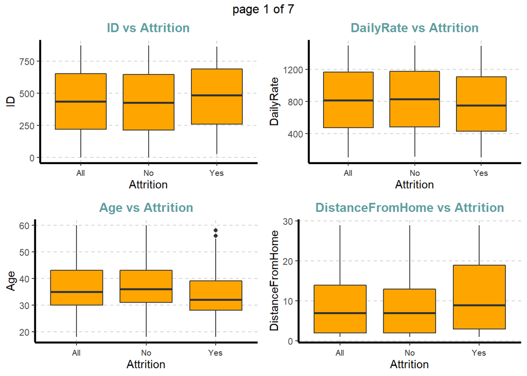

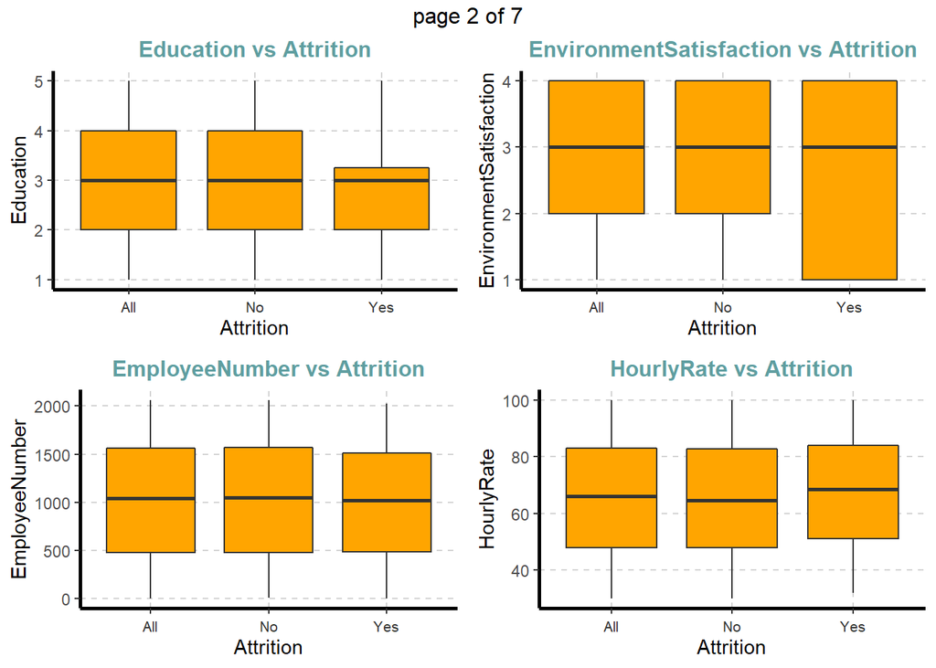

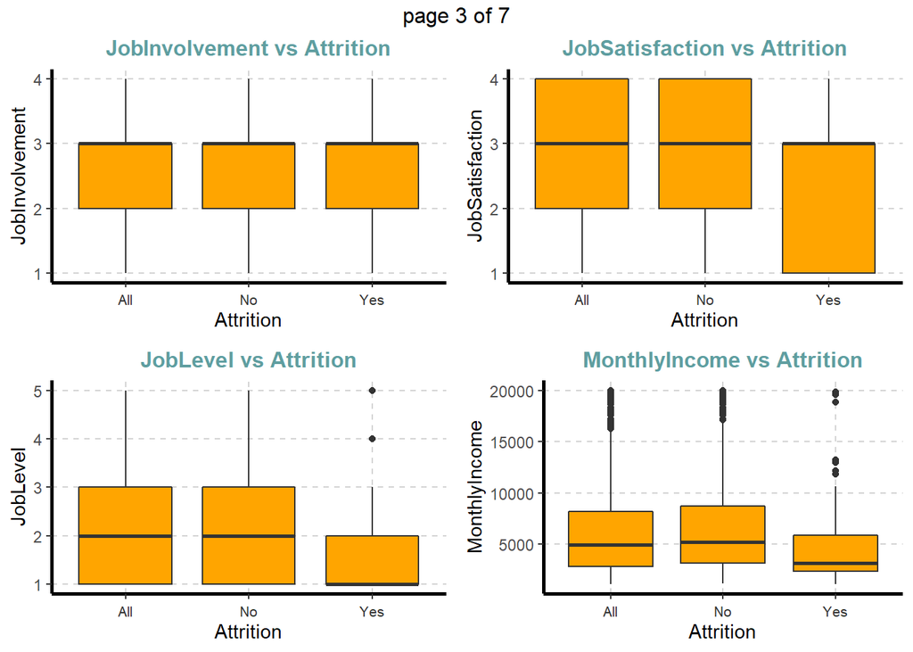

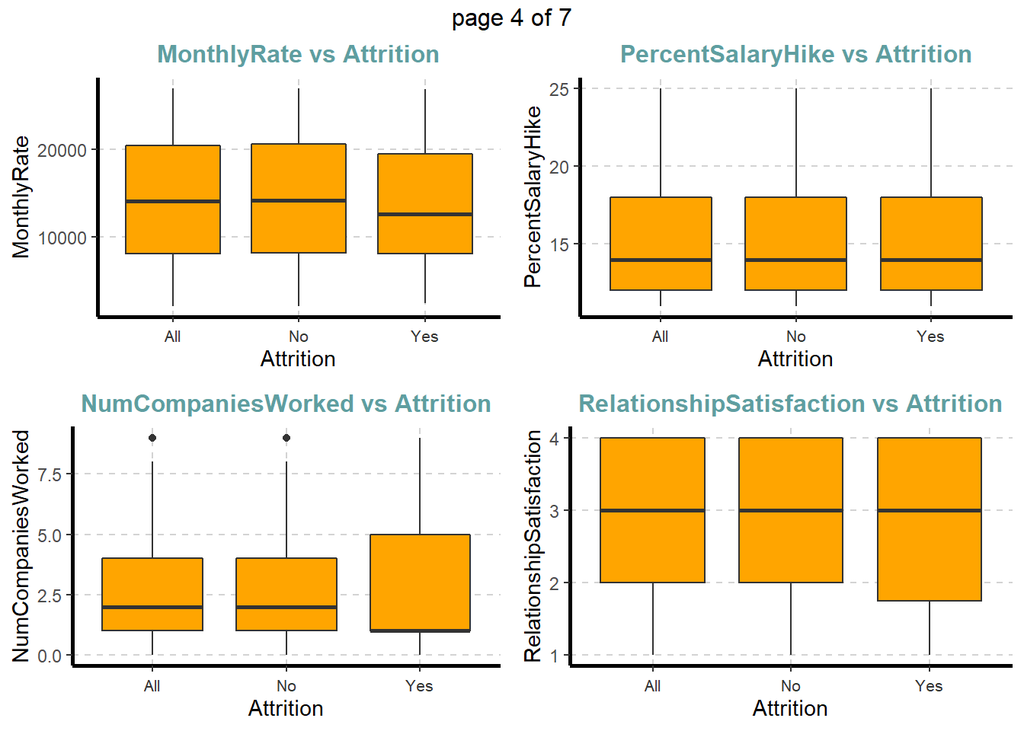

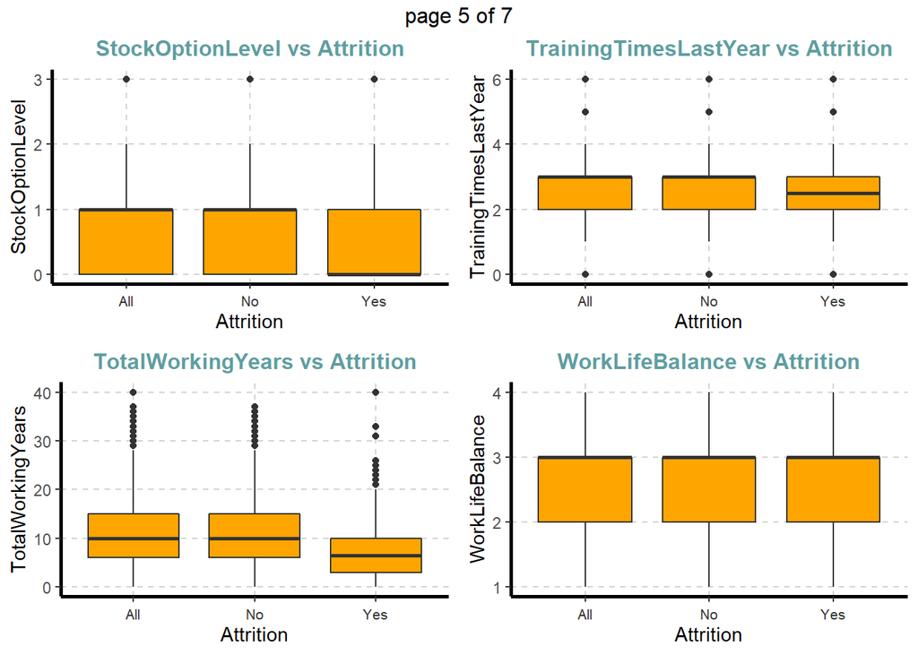

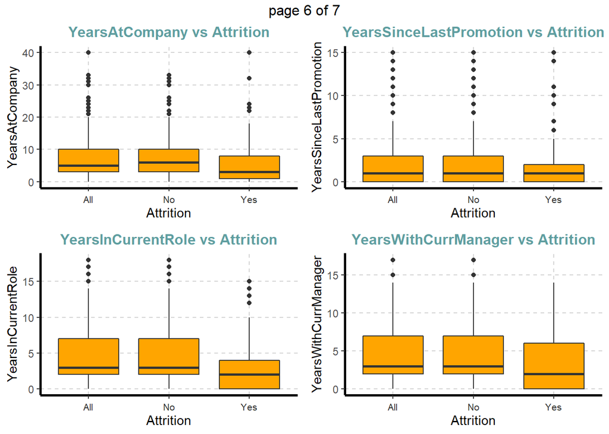

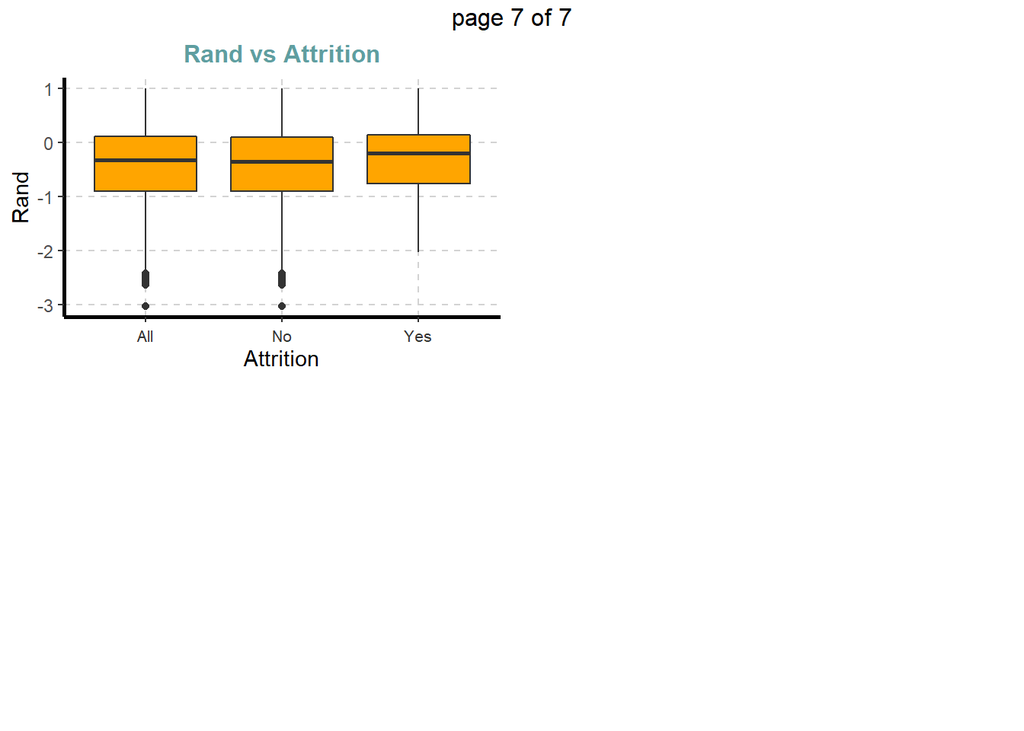

```r
box_plot<-ExpNumViz(turnover, gp="Attrition", type=1, nlim=NULL, fname=NULL, col=c("pink", "yellow", "orange"),Page=c(2,2),sample=26)
box_plot
```

```r
cat_sum<-ExpCTable(turnover, Target="Attrition", margin=1, clim=10, nlim=NULL, round=2, bin=NULL,per=F)
kable(cat_sum) %>% kable_styling(bootstrap_options = "striped", full_width = F, position = "center")
```

| VARIABLE | CATEGORY | Attrition:No | Attrition:Yes | TOTAL |
| --- | --- | --- | --- | --- |
| BusinessTravel | Non-Travel | 83 | 11 | 94 |
| BusinessTravel | Travel_Frequently | 123 | 35 | 158 |
| BusinessTravel | Travel_Rarely | 524 | 94 | 618 |
| BusinessTravel | TOTAL | 730 | 140 | 870 |
| Department | Human Resources | 29 | 6 | 35 |
| Department | Research & Development | 487 | 75 | 562 |
| Department | Sales | 214 | 59 | 273 |
| Department | TOTAL | 730 | 140 | 870 |
| EducationField | Human Resources | 11 | 4 | 15 |
| EducationField | Life Sciences | 305 | 53 | 358 |
| EducationField | Marketing | 80 | 20 | 100 |
| EducationField | Medical | 233 | 37 | 270 |
| EducationField | Other | 43 | 9 | 52 |
| EducationField | Technical Degree | 58 | 17 | 75 |
| EducationField | TOTAL | 730 | 140 | 870 |
| Gender | Female | 301 | 53 | 354 |
| Gender | Male | 429 | 87 | 516 |
| Gender | TOTAL | 730 | 140 | 870 |
| JobRole | Healthcare Representative | 68 | 8 | 76 |
| JobRole | Human Resources | 21 | 6 | 27 |
| JobRole | Laboratory Technician | 123 | 30 | 153 |
| JobRole | Manager | 47 | 4 | 51 |
| JobRole | Manufacturing Director | 85 | 2 | 87 |
| JobRole | Research Director | 50 | 1 | 51 |
| JobRole | Research Scientist | 140 | 32 | 172 |
| JobRole | Sales Executive | 167 | 33 | 200 |
| JobRole | Sales Representative | 29 | 24 | 53 |
| JobRole | TOTAL | 730 | 140 | 870 |
| MaritalStatus | Divorced | 179 | 12 | 191 |
| MaritalStatus | Married | 352 | 58 | 410 |
| MaritalStatus | Single | 199 | 70 | 269 |
| MaritalStatus | TOTAL | 730 | 140 | 870 |
| OverTime | No | 558 | 60 | 618 |
| OverTime | Yes | 172 | 80 | 252 |
| OverTime | TOTAL | 730 | 140 | 870 |
| PerformanceRating | 3 | 621 | 117 | 738 |
| PerformanceRating | 4 | 109 | 23 | 132 |
| PerformanceRating | TOTAL | 730 | 140 | 870 |

```r
assoc<-ExpCatStat(turnover, Target="Attrition",result="Stat", clim=10, nlim=5, Pclass="Yes")
kable(assoc) %>% kable_styling(bootstrap_options = "striped", full_width = F, position = "center")
```

| Variable | Target | Unique | Chi-squared | p-value | df | IV Value | Cramers V | Degree of Association | Predictive Power |
| --- | --- | --- | --- | --- | --- | --- | --- | --- | --- |
| BusinessTravel | Attrition | 3 | 5.994 | 0.05 | 2 | 0.049 | 0.08 | Very Weak | Not Predictive |
| Department | Attrition | 3 | 9.329 | 0.009 | 2 | 0.075 | 0.1 | Weak | Not Predictive |
| EducationField | Attrition | 6 | 6.411 | 0.268 | 5 | 0.05 | 0.09 | Weak | Not Predictive |
| Gender | Attrition | 2 | 0.424 | 0.515 | 1 | 0.005 | 0.02 | Very Weak | Not Predictive |
| JobRole | Attrition | 9 | 60.543 | 0 | 8 | 0.614 | 0.26 | Moderate | Highly Predictive |
| MaritalStatus | Attrition | 3 | 34.406 | 0 | 2 | 0.313 | 0.2 | Moderate | Highly Predictive |
| OverTime | Attrition | 2 | 62.762 | 0 | 1 | 0.489 | 0.27 | Moderate | Highly Predictive |
| Education | Attrition | 5 | 2.614 | 0.624 | 4 | 0.025 | 0.05 | Very Weak | Not Predictive |
| EnvironmentSatisfaction | Attrition | 4 | 11.231 | 0.011 | 3 | 0.085 | 0.11 | Weak | Not Predictive |
| JobInvolvement | Attrition | 4 | 41.465 | 0 | 3 | 0.271 | 0.22 | Moderate | Medium Predictive |
| JobLevel | Attrition | 5 | 41.533 | 0 | 4 | 0.366 | 0.22 | Moderate | Highly Predictive |
| JobSatisfaction | Attrition | 4 | 11.109 | 0.011 | 3 | 0.101 | 0.11 | Weak | Somewhat Predictive |
| PerformanceRating | Attrition | 2 | 0.105 | 0.746 | 1 | 0.001 | 0.01 | Very Weak | Not Predictive |
| RelationshipSatisfaction | Attrition | 4 | 3.125 | 0.373 | 3 | 0.025 | 0.06 | Very Weak | Not Predictive |
| StockOptionLevel | Attrition | 4 | 56.245 | 0 | 3 | 0.554 | 0.25 | Moderate | Highly Predictive |
| WorkLifeBalance | Attrition | 4 | 14.325 | 0.002 | 3 | 0.093 | 0.13 | Weak | Somewhat Predictive |

```
## $`0`
```

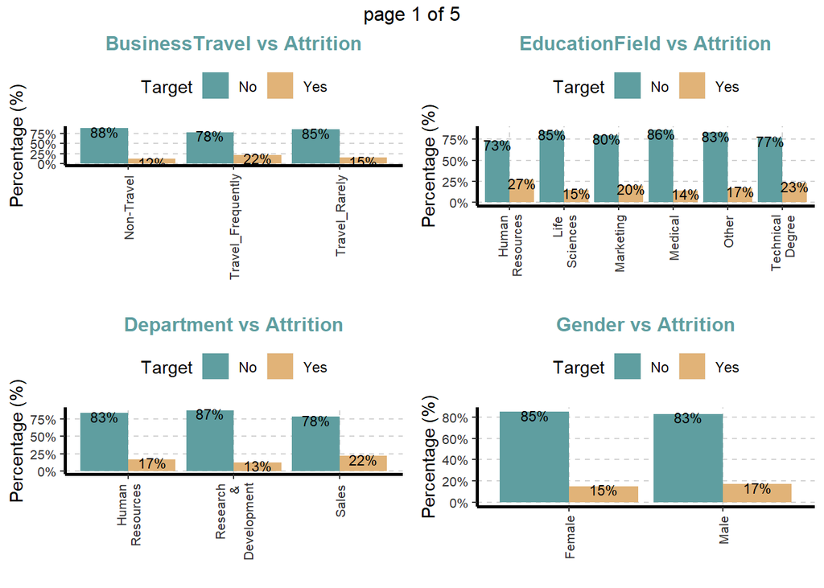

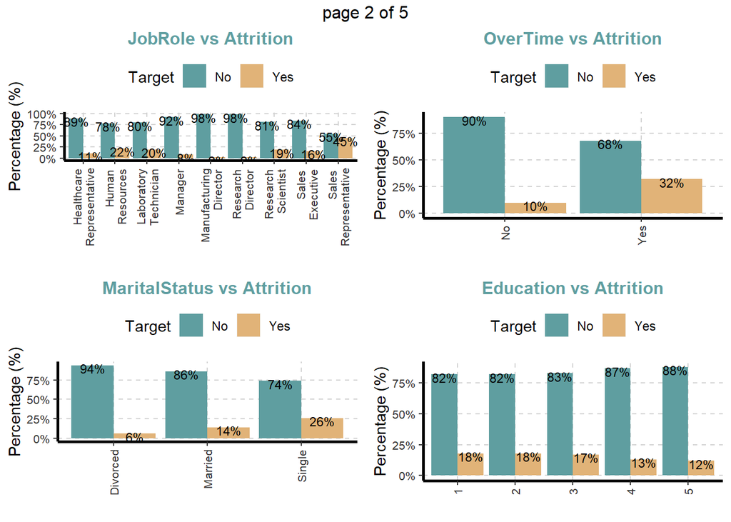

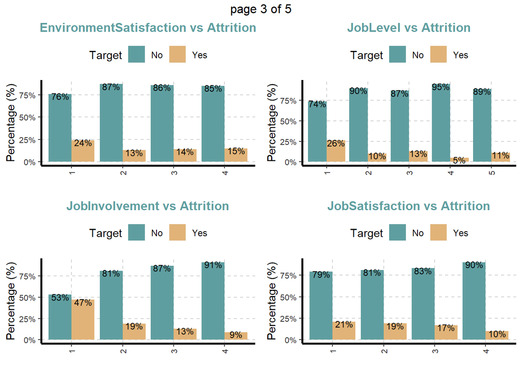

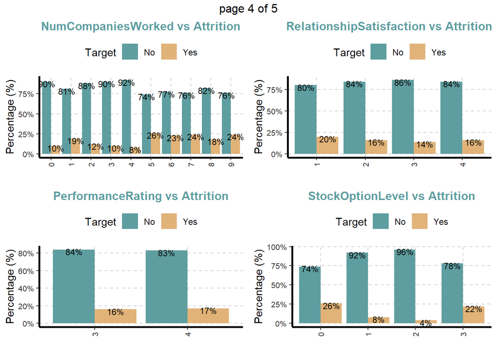

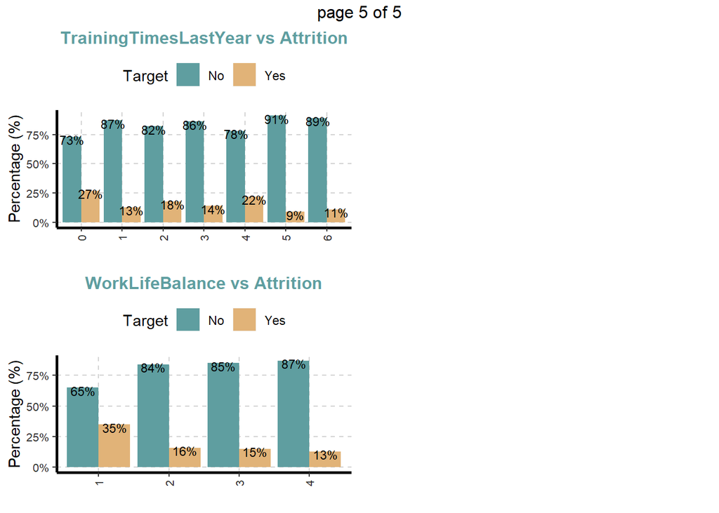

```r
cat_bar_plot<-ExpCatViz(turnover, gp="Attrition", fname=NULL, clim=10, col=NULL, margin=2, Page=c(2,2), sample=35)
cat_bar_plot
```

From the barplots of categorical variables in relation to Attrition, the following discoveries were made:

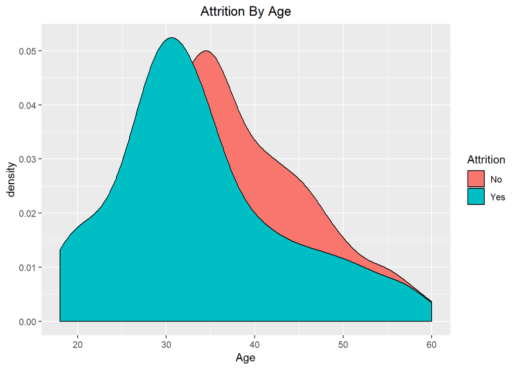

```r
#Attrition vs Age
age <- ggplot(turnover,aes(Age,fill=Attrition))+geom_density() + theme(plot.title = element_text(hjust = 0.5)) +  ggtitle("Attrition By Age")
age
```

The younger the age group, the more attrition occurs.

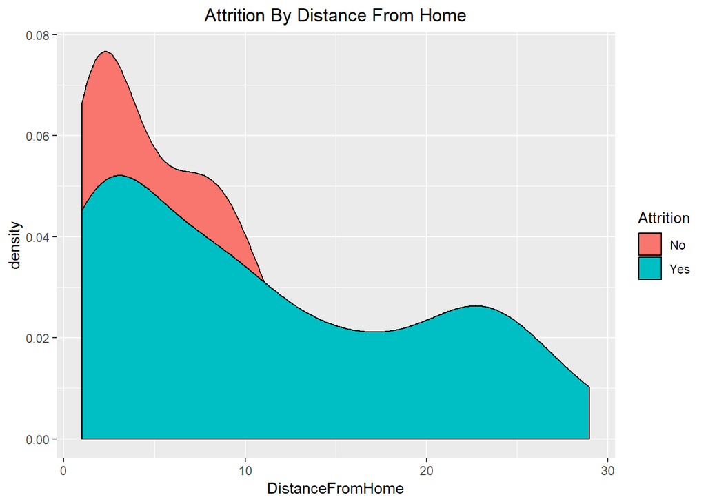

```r
dist <- ggplot(turnover,aes(DistanceFromHome,fill=Attrition))+geom_density() + theme(plot.title = element_text(hjust = 0.5)) +  ggtitle("Attrition By Distance From Home")
dist
```

The further an Employee lives from work, the more likely attrition will occur.

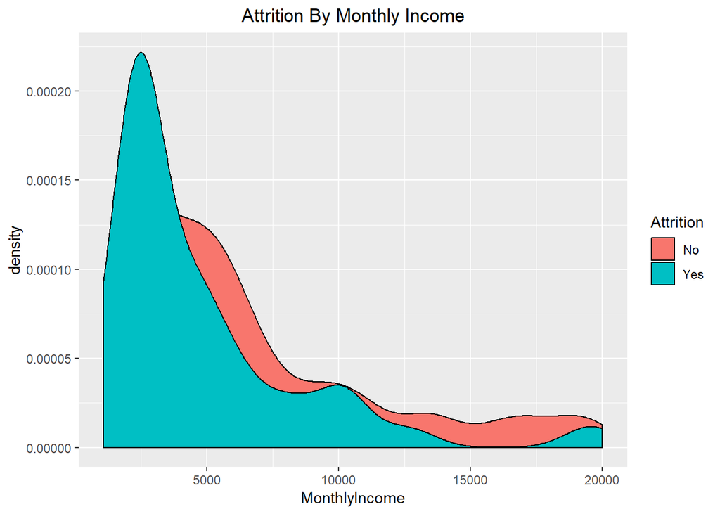

```r
#Attriton vs MonthlyIncome
monInc <- ggplot(turnover,aes(MonthlyIncome,fill=Attrition))+geom_density() + theme(plot.title = element_text(hjust = 0.5)) +  ggtitle("Attrition By Monthly Income")
monInc
```

The lower the monthly income for an employee at Frito Lay, the more likely attrition will occur.

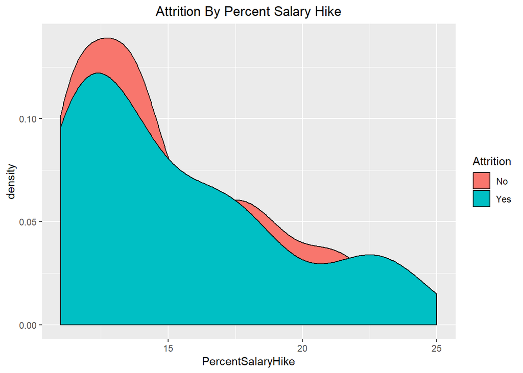

```r
PSH <- ggplot(turnover,aes(PercentSalaryHike,fill=Attrition))+geom_density() + theme(plot.title = element_text(hjust = 0.5)) +  ggtitle("Attrition By Percent Salary Hike")
PSH
```

Here we can visually see that the lower the percent salary increase, the more likely attrition will not occur, so we will not use PercentSalaryHike as a likely predictor or attrition occurance.

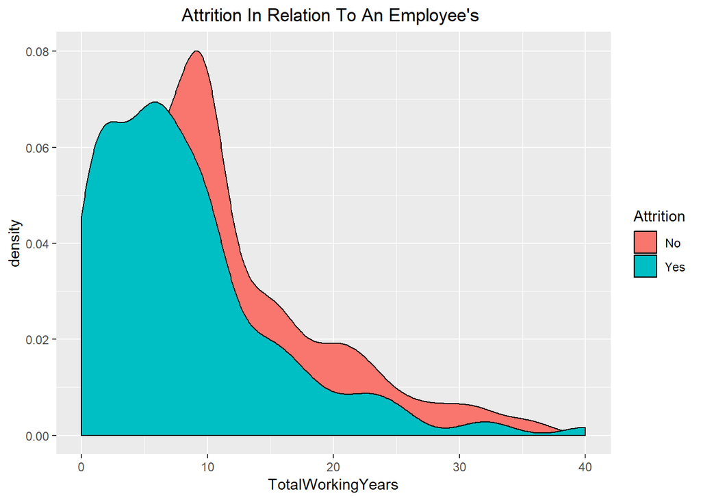

```r
TWY <- ggplot(turnover,aes(TotalWorkingYears,fill=Attrition))+geom_density() + theme(plot.title = element_text(hjust = 0.5)) +  ggtitle("Attrition In Relation To An Employee's ")
TWY
```

The less years an employee spends working for Frito Lay, the more likely attrition will occur.

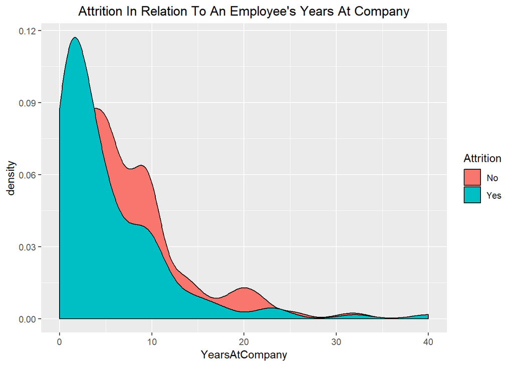

```r
YAC <- ggplot(turnover,aes(YearsAtCompany,fill=Attrition))+geom_density() + theme(plot.title = element_text(hjust = 0.5)) +  ggtitle("Attrition In Relation To An Employee's Years At Company")
YAC
```

The less number of years an employee spends working for Frito Lay, the more likely attrition will occur.

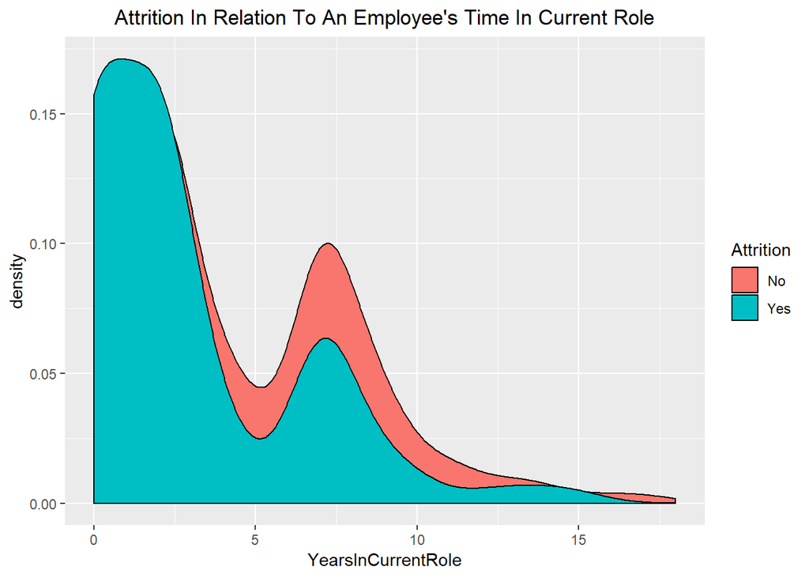

```r
#Attrition vs YearsInCurrentRole
YCR <- ggplot(turnover,aes(YearsInCurrentRole,fill=Attrition))+geom_density() + theme(plot.title = element_text(hjust = 0.5)) +  ggtitle("Attrition In Relation To An Employee's Time In Current Role")
YCR
```

The least number of years and employee spends in their current role, the more likely attrition will occur.

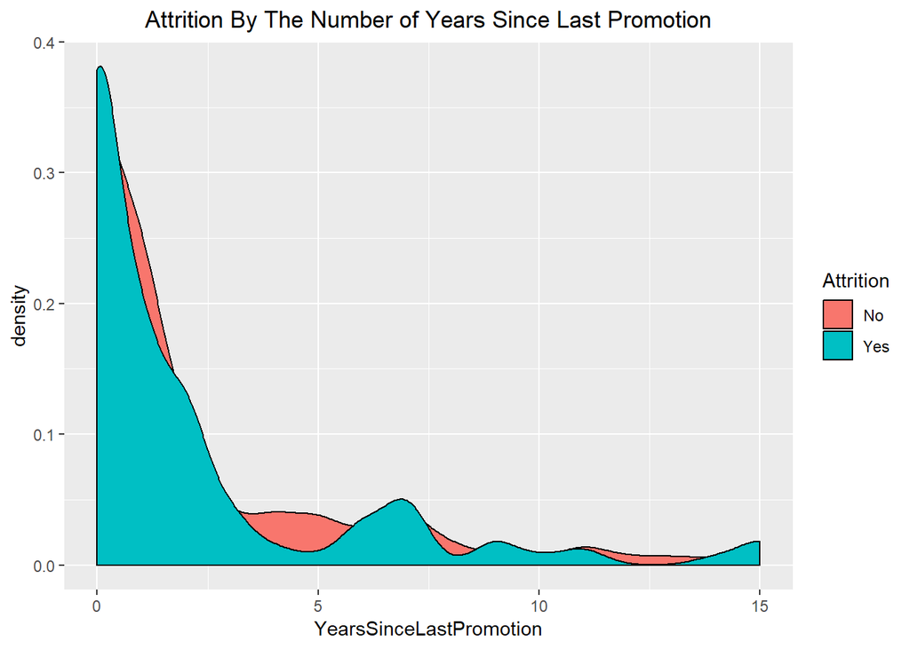

```r
#Attrition vs YearsSinceLastPromotion
 YSLP <- ggplot(turnover,aes(YearsSinceLastPromotion,fill=Attrition))+geom_density() + theme(plot.title = element_text(hjust = 0.5)) +  ggtitle("Attrition By The Number of Years Since Last Promotion")
YSLP
```

[figure not shown]

```r
#Attrition vs YearsWithCurrentManager
YWCM <- ggplot(turnover,aes(YearsWithCurrManager,fill=Attrition))+geom_density() + theme(plot.title = element_text(hjust = 0.5)) +  ggtitle("Attrition By Monthly Income")
YWCM
```

The least amount of years an employee spends with the current manager, the more likely for attrition to occur.

After exploring each variable in relation to attrition, using Logistic Regression, Naive Bayes, and Random Forest Regressor, a model will be built using the training set, then the test set will be used to predict attrition. The predictors that will be used are Age, BusinessTravel, Department, EducationField,Education, Gender, JobRole, MaritalStatus, OverTime, DistanceFromHome, MonthlyIncome, RelationshipSatisfaction, TrainingTimesLastYear, TotalWorkingYears, WorkLifeBalance, YearsAtCompany, YearsInCurrentRole, YearsSinceLastPromotion, YearsWithCurrManager, and StockOptionLevel (20 Predictors).

## Building Predictive Model For Attrition

After exploring each variable in relation to attrition, using Logistic Regression, Naive Bayes, and Random Forest Regressor, a model will be built using the training set, then the test set will be used to predict attrition.Possible predictors that could be used (after EDA) are Age, BusinessTravel, Department, EducationField,Education, Gender, JobRole, MaritalStatus, OverTime, DistanceFromHome, MonthlyIncome, RelationshipSatisfaction, TrainingTimesLastYear, TotalWorkingYears, WorkLifeBalance, YearsAtCompany, YearsInCurrentRole, YearsSinceLastPromotion, YearsWithCurrManager, and StockOptionLevel (20 Predictors).

### Building Test/Train Set

```r
#Deleting columns not needed and Variables that are factors with 1 level
drop<-c("Over18", "DailyRate", "EmployeeCount", "EmployeeNumber", "HourlyRate", "MonthlyRate", "StandardHours", "Rand")

turnover2<-turnover[,!(names(turnover) %in% drop)]

set.seed(222)
split = sample.split(turnover2$Attrition, SplitRatio = 0.7)
turn.train = subset(turnover2, split == TRUE)
turn.test = subset(turnover2, split == FALSE)

table(turn.train$Attrition) %>% prop.table()
```

```
##
##        No       Yes
## 0.8390805 0.1609195
```

```r
table(turn.test$Attrition) %>% prop.table()
```

```
##
##        No       Yes
## 0.8390805 0.1609195
```

### Correlation Plot

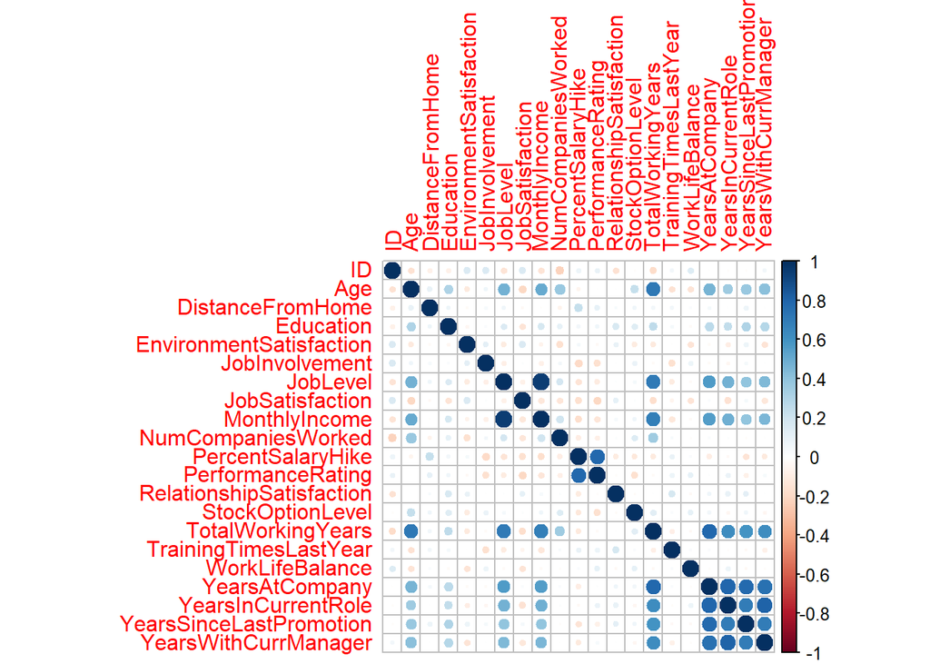

```r
turn.train %>%
  filter(Attrition == "Yes") %>%
  select_if(is.numeric) %>%
  cor() %>%
  corrplot::corrplot()
```

```r
full<-glm(Attrition~., family= binomial, data=turn.train)
summary(full)
```

```
##
## Call:
## glm(formula = Attrition ~ ., family = binomial, data = turn.train)
##
## Deviance Residuals:
##      Min        1Q    Median        3Q       Max
## -2.09840  -0.38193  -0.13583  -0.00774   2.86525
##
## Coefficients:
##                                      Estimate   Std. Error z value
## (Intercept)                       -26.6268723 2844.3881044  -0.009
## ID                                  0.0006624    0.0006657   0.995
## Age                                -0.0790240    0.0258162  -3.061
## BusinessTravelTravel_Frequently     1.9019613    0.6997279   2.718
## BusinessTravelTravel_Rarely         0.8934275    0.5902781   1.514
## DepartmentResearch & Development   17.0363457 2087.5334879   0.008
## DepartmentSales                    14.8126417 2087.5335839   0.007
## DistanceFromHome                    0.0688011    0.0202546   3.397
## Education                           0.3185100    0.1765819   1.804
## EducationFieldLife Sciences        14.5069696 1932.0302471   0.008
## EducationFieldMarketing            15.1776601 1932.0303085   0.008
## EducationFieldMedical              14.8660215 1932.0302336   0.008
## EducationFieldOther                14.7629191 1932.0302666   0.008
## EducationFieldTechnical Degree     14.9983092 1932.0302874   0.008
## EnvironmentSatisfaction            -0.4503136    0.1582761  -2.845
## GenderMale                          0.2248296    0.3346227   0.672
## JobInvolvement                     -0.9765065    0.2260417  -4.320
## JobLevel                           -0.0107363    0.5868360  -0.018
## JobRoleHuman Resources             18.1193666 2087.5340664   0.009
## JobRoleLaboratory Technician        1.7688206    0.8166898   2.166
## JobRoleManager                      0.7327061    1.5899907   0.461
## JobRoleManufacturing Director      -1.4982868    1.0166703  -1.474
## JobRoleResearch Director          -18.4087754  793.1301408  -0.023
## JobRoleResearch Scientist           0.7992959    0.7925891   1.008
## JobRoleSales Executive              2.7715526    1.8141586   1.528
## JobRoleSales Representative         5.2466291    1.9362321   2.710
## JobSatisfaction                    -0.7772993    0.1580550  -4.918
## MaritalStatusMarried                0.8056958    0.5145890   1.566
## MaritalStatusSingle                 1.6596516    0.6299406   2.635
## MonthlyIncome                       0.0001109    0.0001612   0.688
```

[output cut: 52 more lines]

```
## WorkLifeBalance                         0.001233 **
## YearsAtCompany                          0.119838
## YearsInCurrentRole                      0.006919 **
## YearsSinceLastPromotion          0.0000265255550 ***
## YearsWithCurrManager                    0.078896 .
## ---
## Signif. codes:  0 '***' 0.001 '**' 0.01 '*' 0.05 '.' 0.1 ' ' 1
##
## (Dispersion parameter for binomial family taken to be 1)
##
##     Null deviance: 537.37  on 608  degrees of freedom
## Residual deviance: 277.51  on 566  degrees of freedom
## AIC: 363.51
##
## Number of Fisher Scoring iterations: 17
```

```r
full$anova
```

#### Logistic Regression: Predictive Model By (Forward Selection)

```r
forward<-stepAIC(full, direction="forward", trace=FALSE)
summary(forward)
```

```
##
## Call:
## glm(formula = Attrition ~ ID + Age + BusinessTravel + Department +
##     DistanceFromHome + Education + EducationField + EnvironmentSatisfaction +
##     Gender + JobInvolvement + JobLevel + JobRole + JobSatisfaction +
##     MaritalStatus + MonthlyIncome + NumCompaniesWorked + OverTime +
##     PercentSalaryHike + PerformanceRating + RelationshipSatisfaction +
##     StockOptionLevel + TotalWorkingYears + TrainingTimesLastYear +
##     WorkLifeBalance + YearsAtCompany + YearsInCurrentRole + YearsSinceLastPromotion +
##     YearsWithCurrManager, family = binomial, data = turn.train)
##
## Deviance Residuals:
##      Min        1Q    Median        3Q       Max
## -2.09840  -0.38193  -0.13583  -0.00774   2.86525
##
## Coefficients:
##                                      Estimate   Std. Error z value
## (Intercept)                       -26.6268723 2844.3881044  -0.009
## ID                                  0.0006624    0.0006657   0.995
## Age                                -0.0790240    0.0258162  -3.061
## BusinessTravelTravel_Frequently     1.9019613    0.6997279   2.718
## BusinessTravelTravel_Rarely         0.8934275    0.5902781   1.514
## DepartmentResearch & Development   17.0363457 2087.5334879   0.008
## DepartmentSales                    14.8126417 2087.5335839   0.007
## DistanceFromHome                    0.0688011    0.0202546   3.397
## Education                           0.3185100    0.1765819   1.804
## EducationFieldLife Sciences        14.5069696 1932.0302471   0.008
## EducationFieldMarketing            15.1776601 1932.0303085   0.008
## EducationFieldMedical              14.8660215 1932.0302336   0.008
## EducationFieldOther                14.7629191 1932.0302666   0.008
## EducationFieldTechnical Degree     14.9983092 1932.0302874   0.008
## EnvironmentSatisfaction            -0.4503136    0.1582761  -2.845
## GenderMale                          0.2248296    0.3346227   0.672
## JobInvolvement                     -0.9765065    0.2260417  -4.320
## JobLevel                           -0.0107363    0.5868360  -0.018
## JobRoleHuman Resources             18.1193666 2087.5340664   0.009
## JobRoleLaboratory Technician        1.7688206    0.8166898   2.166
## JobRoleManager                      0.7327061    1.5899907   0.461
## JobRoleManufacturing Director      -1.4982868    1.0166703  -1.474
## JobRoleResearch Director          -18.4087754  793.1301408  -0.023
```

[output cut: 59 more lines]

```
## WorkLifeBalance                         0.001233 **
## YearsAtCompany                          0.119838
## YearsInCurrentRole                      0.006919 **
## YearsSinceLastPromotion          0.0000265255550 ***
## YearsWithCurrManager                    0.078896 .
## ---
## Signif. codes:  0 '***' 0.001 '**' 0.01 '*' 0.05 '.' 0.1 ' ' 1
##
## (Dispersion parameter for binomial family taken to be 1)
##
##     Null deviance: 537.37  on 608  degrees of freedom
## Residual deviance: 277.51  on 566  degrees of freedom
## AIC: 363.51
##
## Number of Fisher Scoring iterations: 17
```

```r
forward$anova
```

```
## Stepwise Model Path
## Analysis of Deviance Table
##
## Initial Model:
## Attrition ~ ID + Age + BusinessTravel + Department + DistanceFromHome +
##     Education + EducationField + EnvironmentSatisfaction + Gender +
##     JobInvolvement + JobLevel + JobRole + JobSatisfaction + MaritalStatus +
##     MonthlyIncome + NumCompaniesWorked + OverTime + PercentSalaryHike +
##     PerformanceRating + RelationshipSatisfaction + StockOptionLevel +
##     TotalWorkingYears + TrainingTimesLastYear + WorkLifeBalance +
##     YearsAtCompany + YearsInCurrentRole + YearsSinceLastPromotion +
##     YearsWithCurrManager
##
## Final Model:
## Attrition ~ ID + Age + BusinessTravel + Department + DistanceFromHome +
##     Education + EducationField + EnvironmentSatisfaction + Gender +
##     JobInvolvement + JobLevel + JobRole + JobSatisfaction + MaritalStatus +
##     MonthlyIncome + NumCompaniesWorked + OverTime + PercentSalaryHike +
##     PerformanceRating + RelationshipSatisfaction + StockOptionLevel +
##     TotalWorkingYears + TrainingTimesLastYear + WorkLifeBalance +
##     YearsAtCompany + YearsInCurrentRole + YearsSinceLastPromotion +
##     YearsWithCurrManager
##
##
##   Step Df Deviance Resid. Df Resid. Dev      AIC
## 1                        566   277.5097 363.5097
```

```r
backward<-stepAIC(full, direction="backward", trace=FALSE)
summary(backward)
```

```
##
## Call:
## glm(formula = Attrition ~ Age + BusinessTravel + DistanceFromHome +
##     EnvironmentSatisfaction + JobInvolvement + JobRole + JobSatisfaction +
##     MaritalStatus + NumCompaniesWorked + OverTime + RelationshipSatisfaction +
##     TotalWorkingYears + TrainingTimesLastYear + WorkLifeBalance +
##     YearsInCurrentRole + YearsSinceLastPromotion, family = binomial,
##     data = turn.train)
##
## Deviance Residuals:
##     Min       1Q   Median       3Q      Max
## -2.1007  -0.3867  -0.1632  -0.0277   3.5974
##
## Coefficients:
##                                  Estimate Std. Error z value
## (Intercept)                       5.85476    1.56011   3.753
## Age                              -0.06973    0.02485  -2.806
## BusinessTravelTravel_Frequently   1.69616    0.65799   2.578
## BusinessTravelTravel_Rarely       0.83996    0.55544   1.512
## DistanceFromHome                  0.06333    0.01888   3.355
## EnvironmentSatisfaction          -0.39552    0.14825  -2.668
## JobInvolvement                   -0.97338    0.21475  -4.533
## JobRoleHuman Resources            0.61107    1.28178   0.477
## JobRoleLaboratory Technician      1.22466    0.68942   1.776
## JobRoleManager                    0.59791    1.00488   0.595
## JobRoleManufacturing Director    -1.53870    0.99674  -1.544
## JobRoleResearch Director        -15.75121  883.57212  -0.018
## JobRoleResearch Scientist         0.53603    0.69165   0.775
## JobRoleSales Executive            0.70259    0.68126   1.031
## JobRoleSales Representative       2.56392    0.78091   3.283
## JobSatisfaction                  -0.72870    0.14834  -4.912
## MaritalStatusMarried              0.98682    0.47348   2.084
## MaritalStatusSingle               1.86281    0.48960   3.805
## NumCompaniesWorked                0.32648    0.07398   4.413
## OverTimeYes                       2.22698    0.33795   6.590
## RelationshipSatisfaction         -0.41444    0.14095  -2.940
## TotalWorkingYears                -0.08300    0.04506  -1.842
## TrainingTimesLastYear            -0.49381    0.14092  -3.504
## WorkLifeBalance                  -0.70790    0.21506  -3.292
## YearsInCurrentRole               -0.17019    0.06663  -2.554
```

[output cut: 23 more lines]

```
## TotalWorkingYears                      0.065446 .
## TrainingTimesLastYear                  0.000458 ***
## WorkLifeBalance                        0.000996 ***
## YearsInCurrentRole                     0.010638 *
## YearsSinceLastPromotion         0.0000019245499 ***
## ---
## Signif. codes:  0 '***' 0.001 '**' 0.01 '*' 0.05 '.' 0.1 ' ' 1
##
## (Dispersion parameter for binomial family taken to be 1)
##
##     Null deviance: 537.37  on 608  degrees of freedom
## Residual deviance: 290.64  on 583  degrees of freedom
## AIC: 342.64
##
## Number of Fisher Scoring iterations: 17
```

```r
backward$anova
```

```
## Stepwise Model Path
## Analysis of Deviance Table
##
## Initial Model:
## Attrition ~ ID + Age + BusinessTravel + Department + DistanceFromHome +
##     Education + EducationField + EnvironmentSatisfaction + Gender +
##     JobInvolvement + JobLevel + JobRole + JobSatisfaction + MaritalStatus +
##     MonthlyIncome + NumCompaniesWorked + OverTime + PercentSalaryHike +
##     PerformanceRating + RelationshipSatisfaction + StockOptionLevel +
##     TotalWorkingYears + TrainingTimesLastYear + WorkLifeBalance +
##     YearsAtCompany + YearsInCurrentRole + YearsSinceLastPromotion +
##     YearsWithCurrManager
##
## Final Model:
## Attrition ~ Age + BusinessTravel + DistanceFromHome + EnvironmentSatisfaction +
##     JobInvolvement + JobRole + JobSatisfaction + MaritalStatus +
##     NumCompaniesWorked + OverTime + RelationshipSatisfaction +
##     TotalWorkingYears + TrainingTimesLastYear + WorkLifeBalance +
##     YearsInCurrentRole + YearsSinceLastPromotion
##
##
##                      Step Df      Deviance Resid. Df Resid. Dev      AIC
## 1                                                566   277.5097 363.5097
## 2        - EducationField  5 2.22447335800       571   279.7341 355.7341
## 3              - JobLevel  1 0.00001049375       572   279.7341 353.7341
## 4     - PerformanceRating  1 0.08361302296       573   279.8178 351.8178
## 5            - Department  2 2.29439336158       575   282.1121 350.1121
## 6                - Gender  1 0.58079494242       576   282.6929 348.6929
## 7     - PercentSalaryHike  1 0.68716115283       577   283.3801 347.3801
## 8      - StockOptionLevel  1 0.78839380010       578   284.1685 346.1685
## 9         - MonthlyIncome  1 0.90504485319       579   285.0735 345.0735
## 10                   - ID  1 1.12414800962       580   286.1977 344.1977
## 11            - Education  1 1.62736564546       581   287.8251 343.8251
## 12 - YearsWithCurrManager  1 1.62384352256       582   289.4489 343.4489
## 13       - YearsAtCompany  1 1.18628279205       583   290.6352 342.6352
```

```r
step<-stepAIC(full, trace=FALSE)
summary(step)
```

```
##
## Call:
## glm(formula = Attrition ~ Age + BusinessTravel + DistanceFromHome +
##     EnvironmentSatisfaction + JobInvolvement + JobRole + JobSatisfaction +
##     MaritalStatus + NumCompaniesWorked + OverTime + RelationshipSatisfaction +
##     TotalWorkingYears + TrainingTimesLastYear + WorkLifeBalance +
##     YearsInCurrentRole + YearsSinceLastPromotion, family = binomial,
##     data = turn.train)
##
## Deviance Residuals:
##     Min       1Q   Median       3Q      Max
## -2.1007  -0.3867  -0.1632  -0.0277   3.5974
##
## Coefficients:
##                                  Estimate Std. Error z value
## (Intercept)                       5.85476    1.56011   3.753
## Age                              -0.06973    0.02485  -2.806
## BusinessTravelTravel_Frequently   1.69616    0.65799   2.578
## BusinessTravelTravel_Rarely       0.83996    0.55544   1.512
## DistanceFromHome                  0.06333    0.01888   3.355
## EnvironmentSatisfaction          -0.39552    0.14825  -2.668
## JobInvolvement                   -0.97338    0.21475  -4.533
## JobRoleHuman Resources            0.61107    1.28178   0.477
## JobRoleLaboratory Technician      1.22466    0.68942   1.776
## JobRoleManager                    0.59791    1.00488   0.595
## JobRoleManufacturing Director    -1.53870    0.99674  -1.544
## JobRoleResearch Director        -15.75121  883.57212  -0.018
## JobRoleResearch Scientist         0.53603    0.69165   0.775
## JobRoleSales Executive            0.70259    0.68126   1.031
## JobRoleSales Representative       2.56392    0.78091   3.283
## JobSatisfaction                  -0.72870    0.14834  -4.912
## MaritalStatusMarried              0.98682    0.47348   2.084
## MaritalStatusSingle               1.86281    0.48960   3.805
## NumCompaniesWorked                0.32648    0.07398   4.413
## OverTimeYes                       2.22698    0.33795   6.590
## RelationshipSatisfaction         -0.41444    0.14095  -2.940
## TotalWorkingYears                -0.08300    0.04506  -1.842
## TrainingTimesLastYear            -0.49381    0.14092  -3.504
## WorkLifeBalance                  -0.70790    0.21506  -3.292
## YearsInCurrentRole               -0.17019    0.06663  -2.554
```

[output cut: 23 more lines]

```
## TotalWorkingYears                      0.065446 .
## TrainingTimesLastYear                  0.000458 ***
## WorkLifeBalance                        0.000996 ***
## YearsInCurrentRole                     0.010638 *
## YearsSinceLastPromotion         0.0000019245499 ***
## ---
## Signif. codes:  0 '***' 0.001 '**' 0.01 '*' 0.05 '.' 0.1 ' ' 1
##
## (Dispersion parameter for binomial family taken to be 1)
##
##     Null deviance: 537.37  on 608  degrees of freedom
## Residual deviance: 290.64  on 583  degrees of freedom
## AIC: 342.64
##
## Number of Fisher Scoring iterations: 17
```

```r
step$anova
```

```
## Stepwise Model Path
## Analysis of Deviance Table
##
## Initial Model:
## Attrition ~ ID + Age + BusinessTravel + Department + DistanceFromHome +
##     Education + EducationField + EnvironmentSatisfaction + Gender +
##     JobInvolvement + JobLevel + JobRole + JobSatisfaction + MaritalStatus +
##     MonthlyIncome + NumCompaniesWorked + OverTime + PercentSalaryHike +
##     PerformanceRating + RelationshipSatisfaction + StockOptionLevel +
##     TotalWorkingYears + TrainingTimesLastYear + WorkLifeBalance +
##     YearsAtCompany + YearsInCurrentRole + YearsSinceLastPromotion +
##     YearsWithCurrManager
##
## Final Model:
## Attrition ~ Age + BusinessTravel + DistanceFromHome + EnvironmentSatisfaction +
##     JobInvolvement + JobRole + JobSatisfaction + MaritalStatus +
##     NumCompaniesWorked + OverTime + RelationshipSatisfaction +
##     TotalWorkingYears + TrainingTimesLastYear + WorkLifeBalance +
##     YearsInCurrentRole + YearsSinceLastPromotion
##
##
##                      Step Df      Deviance Resid. Df Resid. Dev      AIC
## 1                                                566   277.5097 363.5097
## 2        - EducationField  5 2.22447335800       571   279.7341 355.7341
## 3              - JobLevel  1 0.00001049375       572   279.7341 353.7341
## 4     - PerformanceRating  1 0.08361302296       573   279.8178 351.8178
## 5            - Department  2 2.29439336158       575   282.1121 350.1121
## 6                - Gender  1 0.58079494242       576   282.6929 348.6929
## 7     - PercentSalaryHike  1 0.68716115283       577   283.3801 347.3801
## 8      - StockOptionLevel  1 0.78839380010       578   284.1685 346.1685
## 9         - MonthlyIncome  1 0.90504485319       579   285.0735 345.0735
## 10                   - ID  1 1.12414800962       580   286.1977 344.1977
## 11            - Education  1 1.62736564546       581   287.8251 343.8251
## 12 - YearsWithCurrManager  1 1.62384352256       582   289.4489 343.4489
## 13       - YearsAtCompany  1 1.18628279205       583   290.6352 342.6352
```

Note: The AIC is 342.64 Here we want the model with the smallest AIC, the predictive model by stepwise selection will be chosen.To increase the accuracy and sensitivity of the best chosen model, the roc function will be used to find the best classifier threshold.

#### Full Model

```r
#finding the best classifier threshold for full model
predict_full <- predict(full,newdata = turn.test,type = 'response')
roc_full<-roc(turn.test$Attrition, predict_full)
roc_full
```

```
##
## Call:
## roc.default(response = turn.test$Attrition, predictor = predict_full)
##
## Data: predict_full in 219 controls (turn.test$Attrition No) < 42 cases (turn.test$Attrition Yes).
## Area under the curve: 0.7078
```

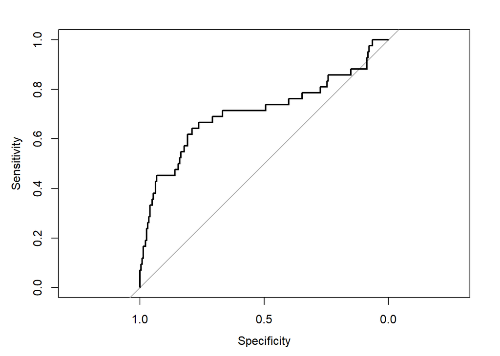

```r
plot(roc_full)
```

```r
res_full<-ifelse(predict_full > 0.17, "Yes", "No")
confusionMatrix(as.factor(res_full), turn.test$Attrition)
```

```
## Confusion Matrix and Statistics
##
##           Reference
## Prediction  No Yes
##        No  173  15
##        Yes  46  27
##
##                Accuracy : 0.7663
##                  95% CI : (0.7102, 0.8163)
##     No Information Rate : 0.8391
##     P-Value [Acc > NIR] : 0.9991301
##
##                   Kappa : 0.3334
##
##  Mcnemar's Test P-Value : 0.0001225
##
##             Sensitivity : 0.7900
##             Specificity : 0.6429
##          Pos Pred Value : 0.9202
##          Neg Pred Value : 0.3699
##              Prevalence : 0.8391
##          Detection Rate : 0.6628
##    Detection Prevalence : 0.7203
##       Balanced Accuracy : 0.7164
##
##        'Positive' Class : No
##
```